# Topic : An Analysis of Food Security in USA - 2021

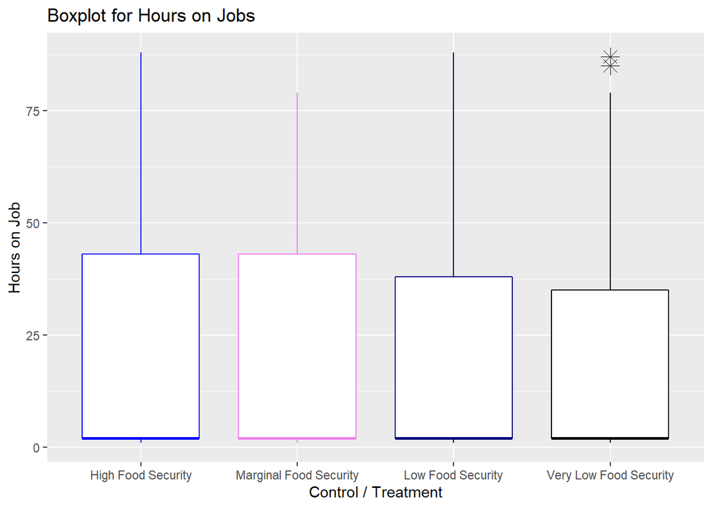

```
##                       Df   Sum Sq Mean Sq F value Pr(>F)
## FoodSecurity_score     3   279623   93208   214.6 <2e-16 ***
## Residuals          71468 31045414     434
## ---
## Signif. codes:  0 '***' 0.001 '**' 0.01 '*' 0.05 '.' 0.1 ' ' 1
```

```
##   Tukey multiple comparisons of means
##     95% family-wise confidence level
##
## Fit: aov(formula = Hours_on_Jobs ~ FoodSecurity_score, data = food_hoj)
##
## $FoodSecurity_score
##                                                     diff       lwr        upr
## Marginal Food Security-High Food Security     -4.2140290 -4.972646 -3.4554123
## Low Food Security-High Food Security          -5.6863555 -6.488530 -4.8841810
## Very Low Food Security-High Food Security     -6.0702228 -7.206149 -4.9342962
## Low Food Security-Marginal Food Security      -1.4723264 -2.531399 -0.4132541
## Very Low Food Security-Marginal Food Security -1.8561937 -3.186036 -0.5263518
## Very Low Food Security-Low Food Security      -0.3838673 -1.739029  0.9712947
##                                                   p adj
## Marginal Food Security-High Food Security     0.0000000
## Low Food Security-High Food Security          0.0000000
## Very Low Food Security-High Food Security     0.0000000
## Low Food Security-Marginal Food Security      0.0020125
## Very Low Food Security-Marginal Food Security 0.0019070
## Very Low Food Security-Low Food Security      0.8860333
```

From the results, it is very clear that the greater F value and smaller P value gives us enough confidence to say that the Hours of work changes significantly with the Food Security Score. Now using Post-Hoc test, it is confirmed that, Marginal Food Security-High Food Security, Low Food Security-High Food Security, Very Low Food Security-High Food Security is significantly different from the other. Also, Low Food Security-Marginal Food Security, Very Low Food Security-Marginal Food Security have significant difference but not as strong as the prior ones. These test results help us to say that Hours on Job per week is affected by the Food insecurity that they face.

### States

#### Plotting barcharts between some states and food security status

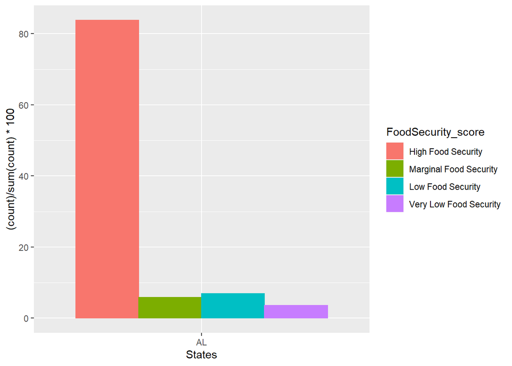

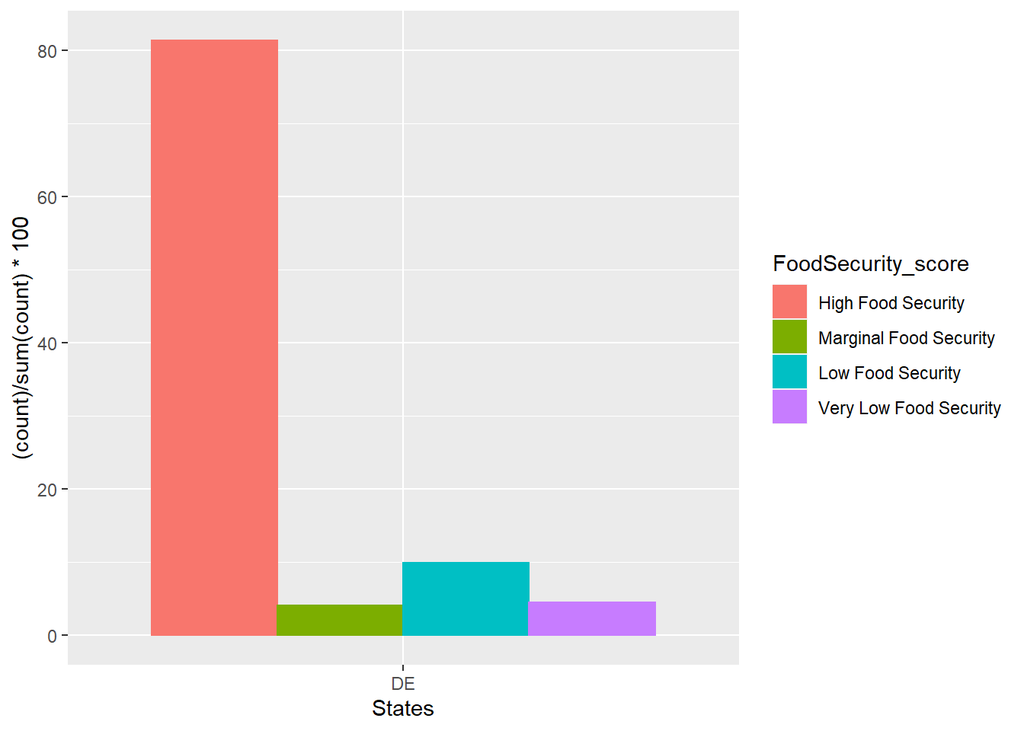

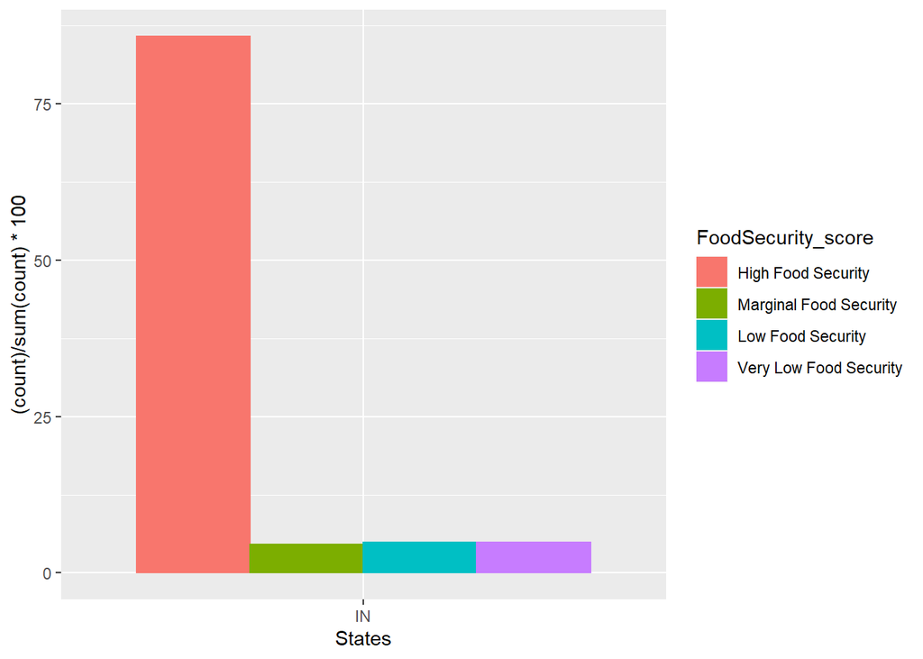

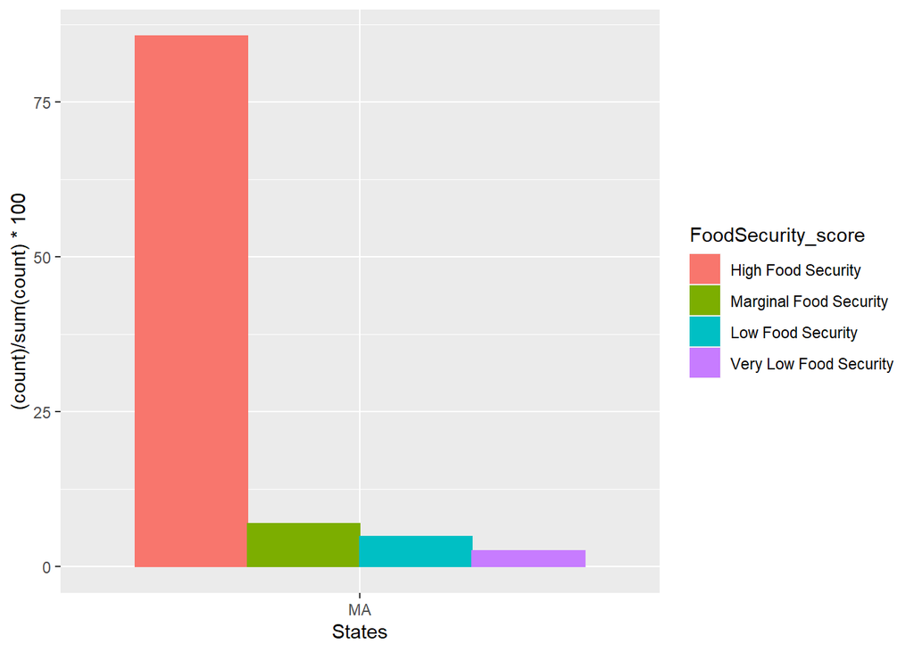

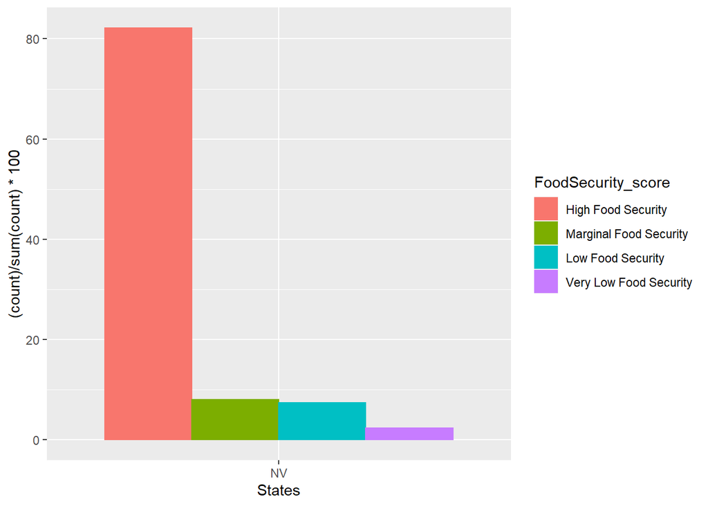

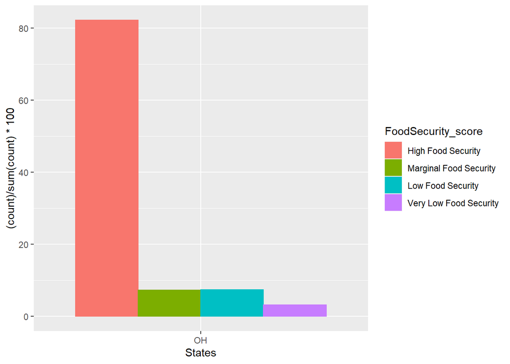

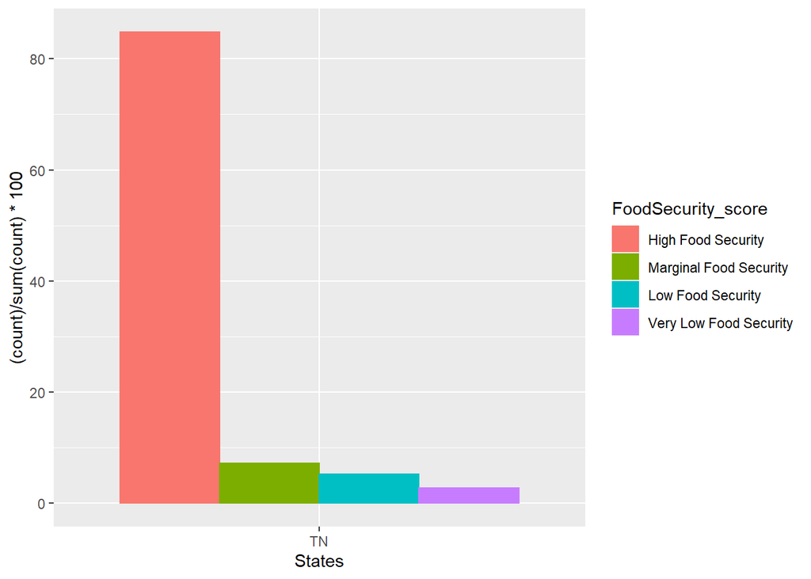

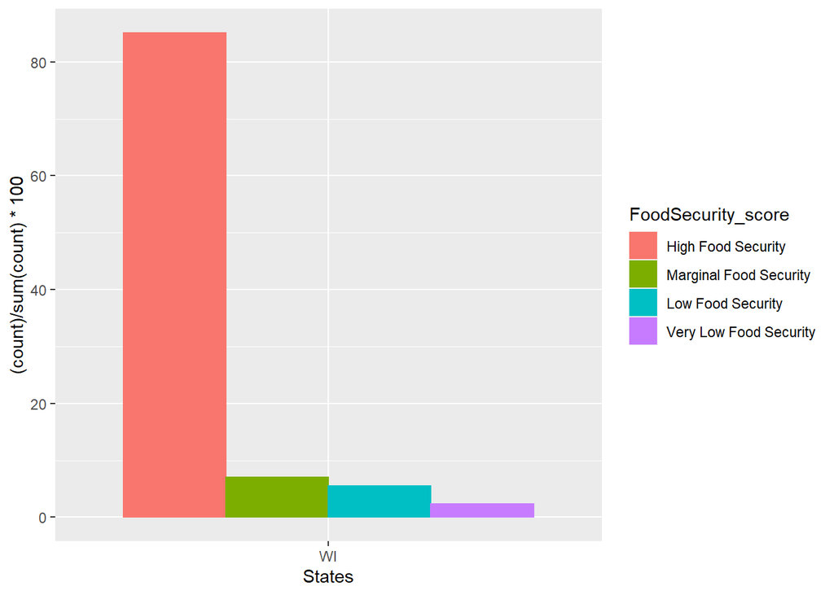

Reference to household income: 1 LESS THAN $5,000 2 5,000 TO 7,499 3 7,500 TO 9,999 4 10,000 TO 12,499 5 12,500 TO 14,999  
6 15,000 TO 19,999 7 20,000 TO 24,999 8 25,000 TO 29,999 9 30,000 TO 34,999 10 35,000 TO 39,999  
11 40,000 TO 49,999 12 50,000 TO 59,999 13 60,000 TO 74,999 14 75,000 TO 99,999 15 100,000 TO 149,999 16 150,000 OR MORE

```
##
##  Pearson's Chi-squared test
##
## data:  income_t
## X-squared = 9512.9, df = 45, p-value < 2.2e-16
```

```
##
##  Pearson's Chi-squared test
##
## data:  family_t
## X-squared = 1691.7, df = 39, p-value < 2.2e-16
```

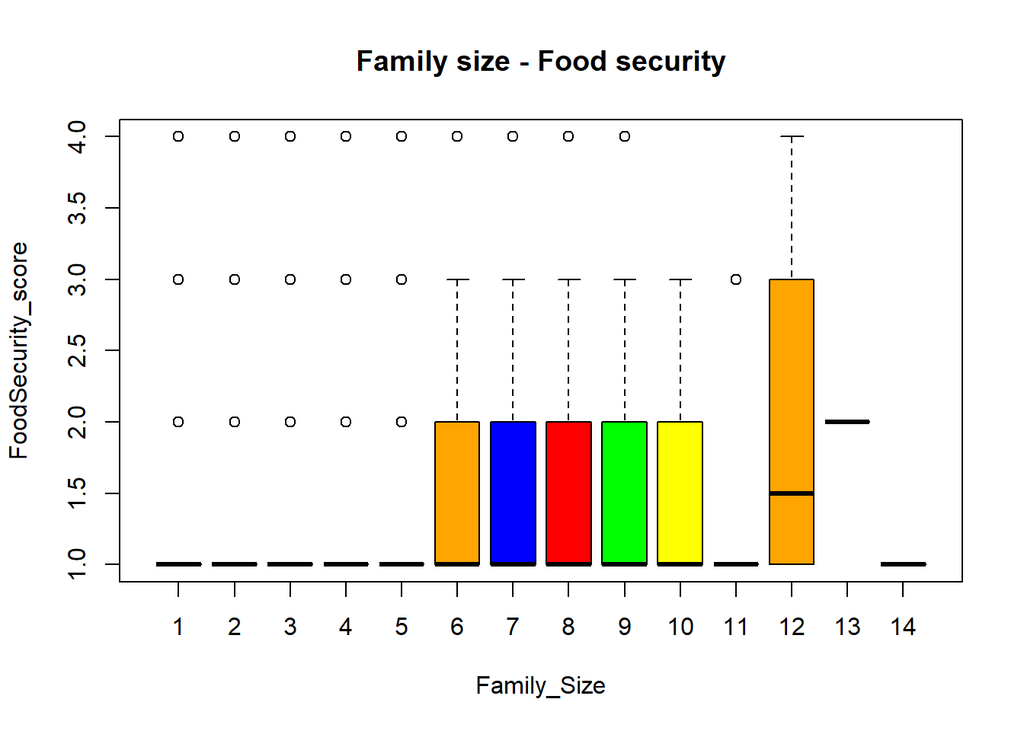

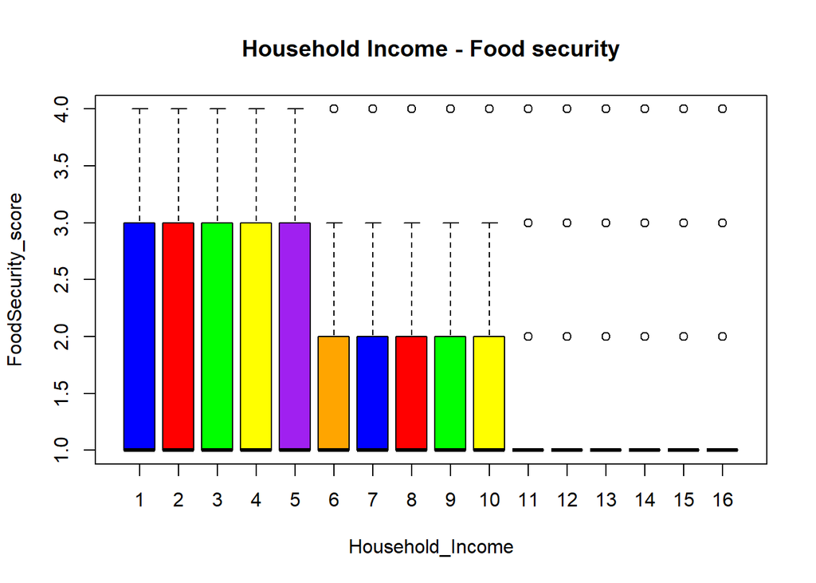

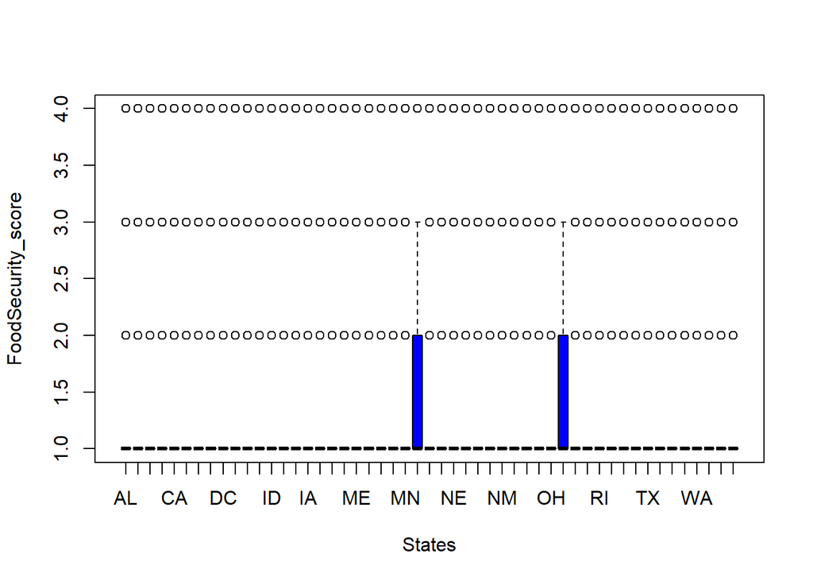

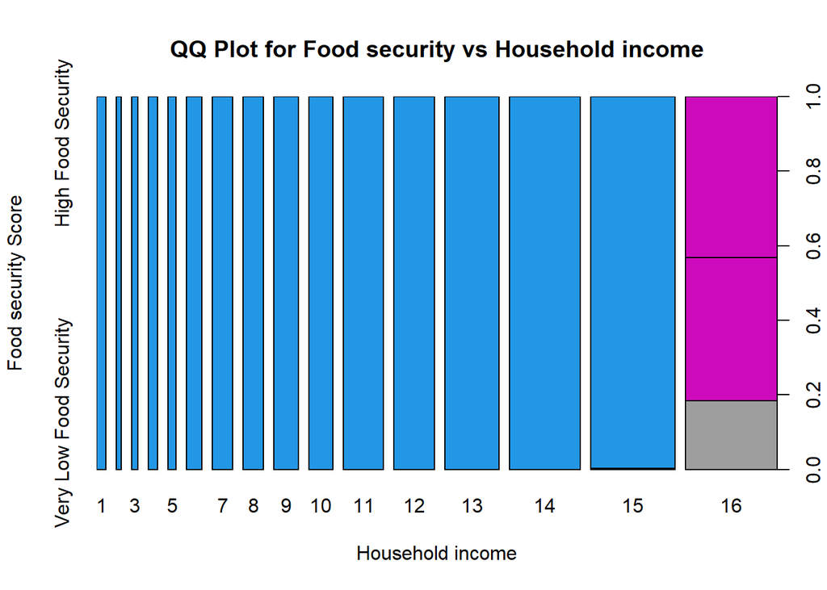

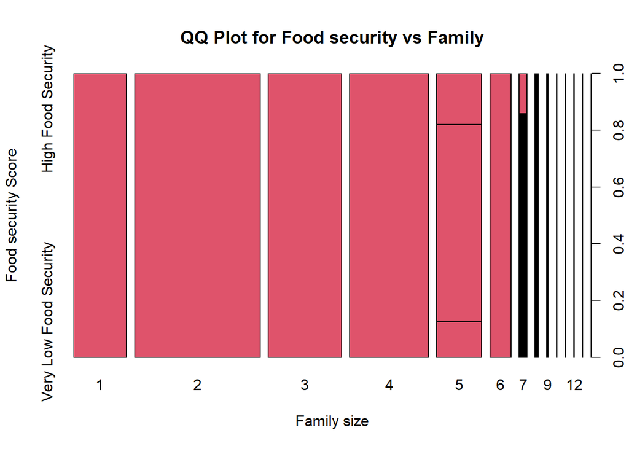

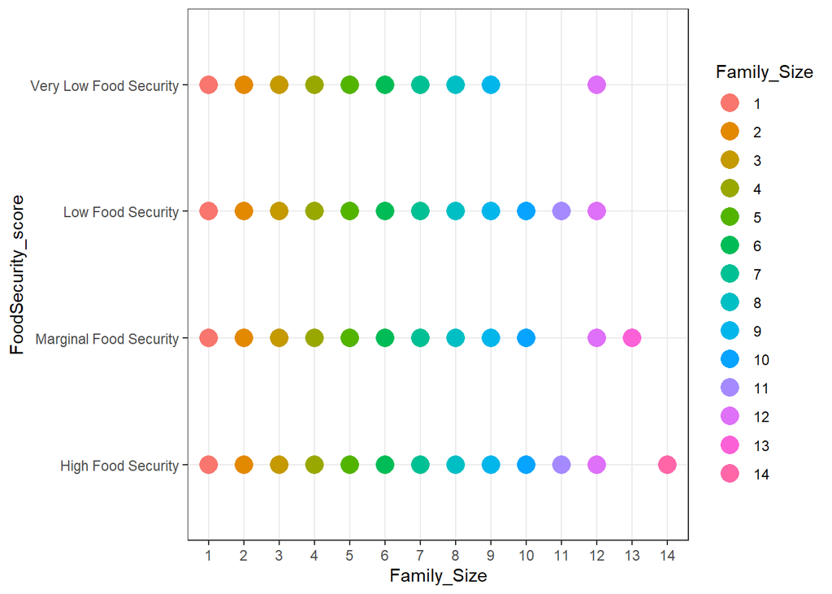

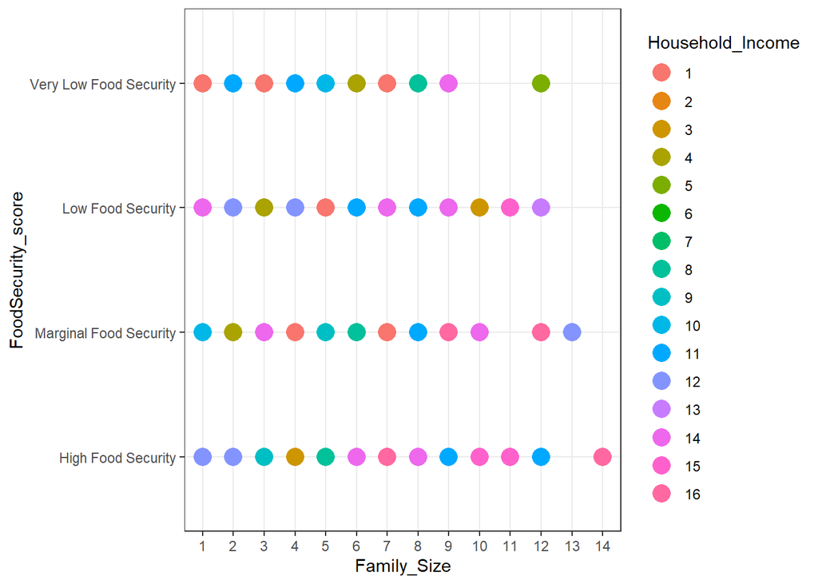

Interesting thing from this graph is that when family size is bigger, household income is high and that family has high food security. When Family size and Household income are separate, they have significant relationship with food security. However, when they are combined together, the result is different. For further analysis, we need to consider age and employment type of the family members.

### Conclusion

Ethnicity, Citizenship, participation in SNAP, Education level, Hours on work, Household income, Family size have significant relation with the Food Security Score. Out of all the chosen variables, these 7 variables showed a relation to food security. But keeping an open mind to possible errors in survey data, it is better to rule out other variables only after further studies.

### Future Scope

The results from the study also shows that further analysis can come up with models to predict the food security score and hence it reveals the important sectors that officials should focus on in order to eradicate food insecurity.  
The initial results shows that 10% of the population are still food insecure in the USA, which accounts for about 33 million people. Food being the vary basic need of any living being, all should have access to safe and proper food. This signifies the result of the study and the further need of studies. We hope that high quality data and thorough analysis will help to eradicate world hunger.